# Lab 3 - Common trends in plankton data

Dynamic Factor Analysis (DFA)

Eric, Madison, Maria

April 20, 2023

# Introduction

This lab focused on dynamic factor analysis, exploring plankton blooms in Lake Washington.

# Data

```r
## load MARSS for data and analyses
library(tidyr)
library(ggplot2)
library(tidyverse)
library(dplyr)
library(forecast)
library(MARSS)
library(corrplot)
library(knitr)

## load the raw data (there are 3 datasets contained here)
data(lakeWAplankton, package = "MARSS")

## we want `lakeWAplanktonTrans`, which has been transformed
## so the 0's are replaced with NA's and the data z-scored
all_dat <- lakeWAplanktonTrans
```

# Methods

## Plankton Selection

**Which plankton taxa did you choose and how did you choose them?**

We selected two primary producers (Diatoms & Other Algae), two grazers (Daphnia & Cyclops), and one predator (Epischura). We wanted to consider potential interaction between species (primary producers, grazers, predators), and also select species that were data-rich for the majority of the time series.

- *Diatoms* (Primary Producer) dominated in early spring time (Phytoplankton)
- *Other Algae* (Primary Producer) –> Various algal species that grazers eat. Complete data set.
- *Daphnia* (Grazer) –> Eat diatoms bloom after diatoms (zooplankton)
- *Cyclops* (Grazer) –> Grazer taxa, eat phytoplankton
- *Epischura* (Predator) –> Calanus Copepod, tend to peak after diatoms

**What time period did you examine and why?**

We are choosing years 1978 to 1985 since Daphnia data is more consistent after 1978 and we are able to capture an interesting trend in Total Phosphorus.

## Wrangle the data

```r
## add some code here

yr_frst <- 1978
yr_last <- 1985
init_dat <- all_dat[all_dat[, "Year"] >= yr_frst &
                      all_dat[, "Year"] <= yr_last,]

# put the 5 response variables in the yt matrix, can be replace whenever
# This represents multiple trophic levels
# Primary prod: Diatoms & Other Algae
# Grazers: Daphnia & Cyclops
# Predators: Epischura
plank_taxa <- c("Diatoms","Other.algae","Daphnia","Cyclops","Epischura")
dat <- init_dat[,plank_taxa] %>%
  t()
## mean of each taxon
y_bar <- apply(dat, 1, mean, na.rm = TRUE)
## subtract the means
plank_dat <- dat - y_bar
## assign new column names
spp <- rownames(plank_dat)
rownames(plank_dat) <- spp

# create a covariates matrix
covnames <- c("Temp","TP","pH") #pH has missing data points so it will only work in certain date ranges
covar <- init_dat[,covnames] %>%
  t()
print(plank_dat[,1:5])
```

```
##                   [,1]        [,2]       [,3]      [,4]       [,5]
## Diatoms      0.1246322  0.30716558  0.3712350 1.4055328  0.2285722
## Other.algae -1.3987376 -1.57104269 -0.6584466 0.7589764 -0.1346297
## Daphnia     -0.9460105 -1.05132054 -0.3179194 0.7737740  1.0986668
## Cyclops      0.3364779 -0.05110172  0.8265634 2.0655099  1.1347830
## Epischura   -0.7829961 -0.82779368 -0.3518153 0.5790608 -0.9097123
```

```r
print(covar[,1:5])
```

```
##            [,1]       [,2]        [,3]      [,4]        [,5]
## Temp -1.1553515 -1.2206156 -1.04048230 -0.555334 -0.03826858
## TP   -0.3389558 -0.1338955  0.01745845 -0.584375 -0.51843108
## pH   -0.7794830 -0.9036437  0.65305114  1.933781 -0.89501851
```

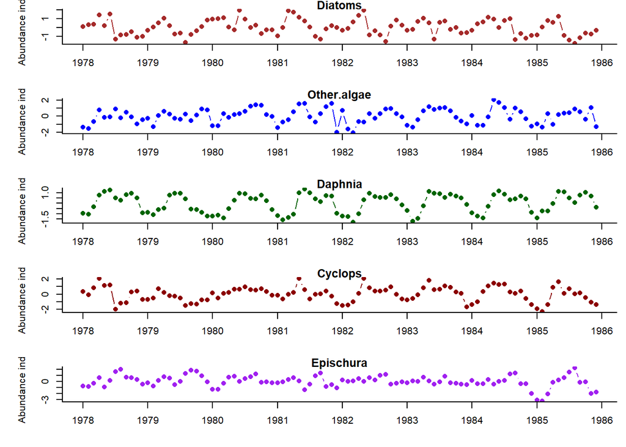

```r
clr <- c("brown", "blue", "darkgreen", "darkred", "purple")

## initialize a counter
cnt <- 1

## set up plotting space & make plots
par(mfrow = c(nrow(plank_dat), 1), mai = c(0.5, 0.7, 0.1, 0.1), omi = c(0, 0, 0, 0))
mm = ncol(plank_dat)

for(i in spp){
  plot(plank_dat[i,],  bty = "L", xaxt = "n", pch = 16,
       xlab = "",
       ylab = "Abundance index", col=clr[cnt], type="b")
  axis(1, 12 * (0:mm) + 1, yr_frst + 0:mm)
  title(i)
  cnt <- cnt + 1
}
```

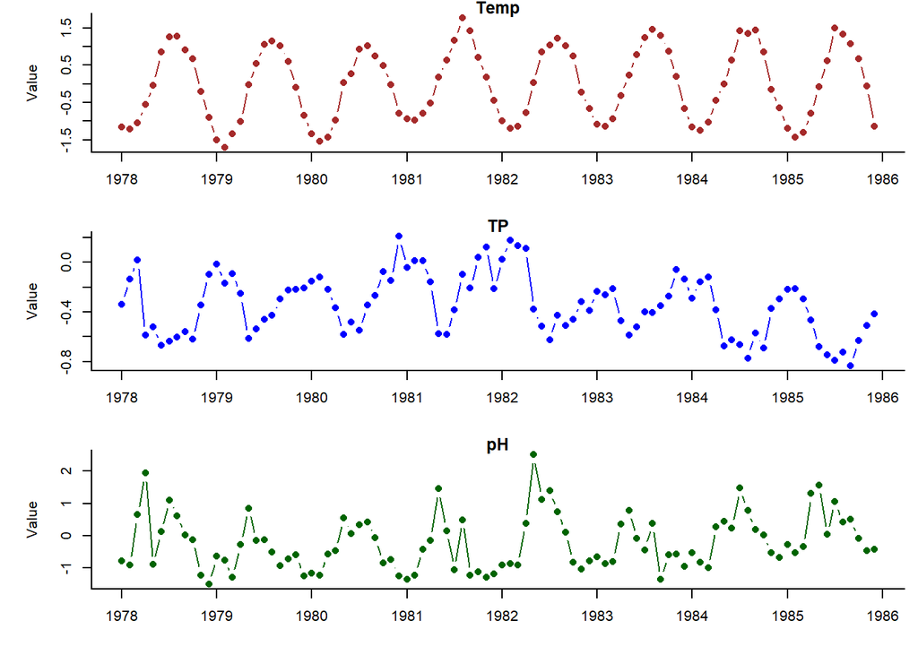

```r
## set plot colors
clr <- c("brown", "blue", "darkgreen","purple")

## initialize a counter
cnt <- 1

## set up plotting space & make plots
par(mfrow = c(nrow(covar), 1), mai = c(0.5, 0.7, 0.1, 0.1), omi = c(0, 0, 0, 0))

for(i in row.names(covar)){
  plot(covar[i,],  bty = "L", xaxt = "n", pch = 16,
       xlab = "",
       ylab = "Value", col=clr[cnt], type="b")
  axis(1, 12 * (0:mm) + 1, yr_frst + 0:mm)
  title(i)
  cnt <- cnt + 1
}
```

## Initial Model Set-up

We examined models that considered three underlying state options: two, three, and four states. We also tested three observation error matrices, diagonal and equal, diagonal and unequal, and equal variance and covariance. We originally were going to include unconstrained but omitted it due to convergence issues. We wanted to explore assumptions for observation error given our uncertainty surrounding collection and counting methods for the data set. Finally, we considered all combinations of three possible covariates, temperature (Temp), total phosphorus (TP), and pH.

```r
model.states <- 2:4
names(model.states) <- c("two_states","three_states","four_states")

# Also testing different observation error matrices
R.models <- c("diagonal and unequal","equalvarcov", "diagonal and equal")

# Also the covariates must be z-scored if the response variables are demeaned
d.models <- list(
  # d1 = "zero", # No covariates
  d2 = zscore(t(init_dat[,"Temp"])), # Temperature
  d3 = zscore(t(init_dat[,"TP"])), # Total Phosphorus
  d4 = zscore(t(init_dat[,"pH"])), # ph
  d5 = zscore(t(init_dat[,c("Temp","TP")])),
  d6 = zscore(t(init_dat[,c("TP", "pH")])),
  d7 = zscore(t(init_dat[,c("Temp", "pH")])),
  d8 = zscore(t(init_dat[,c("Temp","TP", "pH")])) # Temperature and Total Phosphorus
)
names(d.models) <- c("Temp", "TP", "pH", "Temp and TP", "TP and pH", "Temp and pH", "Temp,TP, and pH")

#Define Model List
mod.list = list(
  A = "zero", # this is set to zero because the data has been demeaned
  Q = "identity", # Q is set to the default value, this can also be "diagonal and equal" or "diagonal and unequal"
  x0 = "zero" # x0 can be also be set to "unconstrained" or "unequal" it might be useful to try these later
)

#DFA form for mars model Q--reduces option to streamline run time

# all other params are left to their default settings
```

We then set up for model runs for 63 model runs, looking at various combination of states, covariates (d) and observation error (R).

```r
# Added in another for loop to run through cycling options, be warned, this means there are 80 total models. It takes a long time to run
start.time <- Sys.time()


out.tab <- NULL
fits <- list()
for(i in model.states){
  for (j in 1:length(d.models)){
    for(R.model in R.models){
      fit.model = c(list(m=i, R=R.model), mod.list)

      #MARSS will throw an error if covariates are not a matrix, This will not pass the covariate arg if it does not exist
      #      if(j==1) {
      #      fit <- MARSS(plank_dat, model=fit.model,
      #                form = "dfa", z.score = FALSE, silent = TRUE,
      #                control=list(maxit=2000, allow.degen=TRUE))
      #      }
      #      else {
      fit <- MARSS(plank_dat, model=fit.model,
                   form = "dfa", z.score = FALSE, silent = TRUE,
                   control=list(maxit=800, allow.degen = TRUE),
                   covariates = d.models[[j]])
      #      }

      out=data.frame(States=names(model.states)[i-1],d=names(d.models)[j],R=R.model, #
                     logLik=fit$logLik, AICc=fit$AICc, num.param=fit$num.params,
                     num.iter=fit$numIter, converged=!fit$convergence,
                     stringsAsFactors = FALSE)
      out.tab=rbind(out.tab,out)
      fits=c(fits,list(fit))

    }
  }
}
end.time <- Sys.time()

elapsed.time <- round((end.time - start.time), 3)
print(elapsed.time)
```

```
## Time difference of 42.08 mins
```

```r
min.AICc <- order(out.tab$AICc)
out.tab.1 <- out.tab[min.AICc, ]
out.tab.1
```

```
##          States               d                    R    logLik      AICc
## 19   two_states Temp,TP, and pH diagonal and unequal -461.3723  984.6112
## 37 three_states     Temp and pH diagonal and unequal -465.6312  988.6075
## 40 three_states Temp,TP, and pH diagonal and unequal -460.1504  989.0255
## 61  four_states Temp,TP, and pH diagonal and unequal -460.0915  993.5313
## 58  four_states     Temp and pH diagonal and unequal -466.1926  994.2518
## 16   two_states     Temp and pH diagonal and unequal -472.1331  994.9035
## 31 three_states     Temp and TP diagonal and unequal -474.3998 1006.1448
## 22 three_states            Temp diagonal and unequal -481.1397 1008.4938
## 10   two_states     Temp and TP diagonal and unequal -479.6465 1009.9303
## 1    two_states            Temp diagonal and unequal -485.3761 1010.4043
## 52  four_states     Temp and TP diagonal and unequal -474.7942 1011.4550
## 43  four_states            Temp diagonal and unequal -482.4445 1015.5264
## 20   two_states Temp,TP, and pH          equalvarcov -482.1252 1019.3497
## 21   two_states Temp,TP, and pH   diagonal and equal -483.8513 1020.5659
```

[output cut: 113 more lines]

# Initial Results

The time for all models to fit was approximately 40 min, and the model that has the least AICc is the model with two states, diagonal and unequal errors and all 3 covariates. Many of the models did not converge, which could have been due to data being inconsistent with our model assumptions, insufficient data (we selected a data rich time period, so I’m not sure about this one), or not enough number of iterations for fitting. (MARSS Manual, Chapter 10).

### Matrix for best fit model

What forms of models did you fit (ie, write them out in matrix form)?

$$\begin{bmatrix}
y_1\\
y_2\\
y_3\\
y_4\\
y_5\\
\end{bmatrix}_t
=
\begin{bmatrix}
z_{1,1} & z_{1,2}\\
z_{2,1} & z_{2,2}\\
z_{3,1} & z_{3,2}\\
z_{4,1} & z_{4,2}\\
z_{5,1} & z_{5,2}\\
\end{bmatrix}
*
\begin{bmatrix}
x_1\\
x_2\\
\end{bmatrix}_t
+
\begin{bmatrix}
d_{1,1} & d_{1,2} & d_{1,3}\\
d_{2,1} & d_{2,2} & d_{2,3}\\
d_{3,1} & d_{3,2} & d_{3,3}\\
d_{4,1} & d_{4,2} & d_{4,3}\\
d_{5,1} & d_{5,2} & d_{5,3}\\
\end{bmatrix}
*
\begin{bmatrix}
Temp \\
TP \\
pH\\
\end{bmatrix}_t
+
\begin{bmatrix}
v_1\\
v_2\\
v_3\\
v_4\\
v_5
\end{bmatrix}_t$$

$$\begin{bmatrix}
x_1\\
x_2\\
\end{bmatrix}_t
=
\begin{bmatrix}
1 & 0\\
0 & 1\\
\end{bmatrix}
\begin{bmatrix}
x_1\\
x_2\\
\end{bmatrix}_{t-1}
+
\begin{bmatrix}
w_1\\
w_2\\
\end{bmatrix}_t$$

Process Error

$$\begin{bmatrix}
w_1\\
w_2\\
\end{bmatrix}
\sim MVN
\begin{pmatrix}
\begin{bmatrix}
0\\
0\\
\end{bmatrix},
\begin{bmatrix}
1 & 0\\
0 & 1\\
\end{bmatrix}
\end{pmatrix}$$

Observation Error

$$\begin{bmatrix}
v_1\\
v_2\\
v_3\\
v_4\\
v_5\\
\end{bmatrix}
\sim MVN
\begin{pmatrix}
\begin{bmatrix}
0\\
0\\
0\\
0\\
0\\
\end{bmatrix},
\begin{bmatrix}
r_1 & 0& 0& 0& 0\\
0 & r_2& 0& 0& 0\\
0 & 0& r_3& 0& 0\\
0 & 0& 0& r_4& 0\\
0 & 0& 0& 0& r_5\\
\end{bmatrix}
\end{pmatrix}$$

## Diagnostics

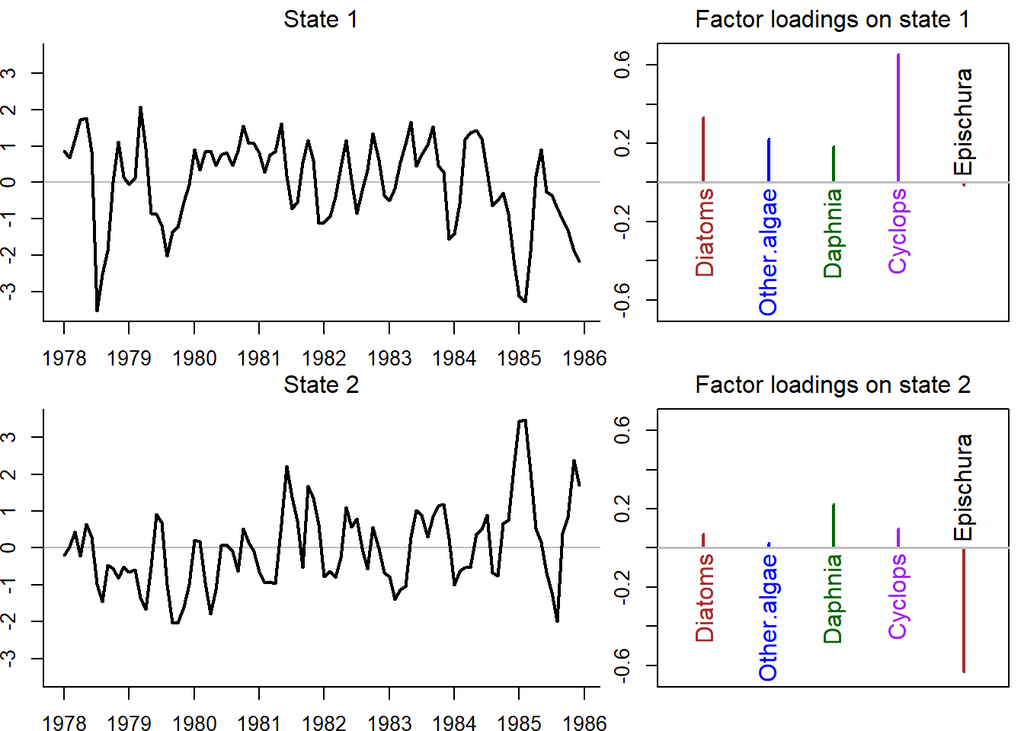

```r
# Rotating the model, plotting the states and loadings
best_fit <- fits[[19]]

# Get Z Estimations and rotate the data
## get the estimated ZZ
Z_est <- coef(best_fit, type = "matrix")$Z

## get the inverse of the rotation matrix
H_inv <- varimax(Z_est)$rotmat

## rotate factor loadings
Z_rot = Z_est %*% H_inv

## rotate processes
proc_rot = solve(H_inv) %*% best_fit$states

N_ts <- nrow(plank_dat)
m = ncol(Z_est)
## plot labels
ylbl <- plank_taxa
w_ts <- seq(mm)

## set up plot area
layout(matrix(1:4, m, 2), widths = c(3,2))
par(mai = c(0.3, 0.3, 0.3, 0.1), omi = c(0, 0, 0, 0))

## plot the processes
for(i in 1:m) {
  ylm <- c(-1, 1) * max(abs(proc_rot[i,]))
  ## set up plot area
  plot(w_ts,proc_rot[i,], type = "n", bty = "L",
       ylim = ylm, xlab = "", ylab = "", xaxt = "n")
  ## draw zero-line
  abline(h = 0, col = "gray")
  ## plot trend line
  lines(w_ts, proc_rot[i,], lwd = 2)
  lines(w_ts, proc_rot[i,], lwd = 2)
  ## add panel labels
  mtext(paste("State",i), side = 3, line = 0.5)
  axis(1, 12 * (0:mm) + 1, yr_frst + 0:mm)
}
## plot the loadings
minZ <- 0
ylm <- c(-1, 1) * max(abs(Z_rot))
for(i in 1:m) {
  plot(x = c(1:N_ts)[abs(Z_rot[,i])>minZ],
       y = as.vector(Z_rot[abs(Z_rot[,i])>minZ,i]),
       type = "h",
       lwd = 2, xlab = "", ylab = "", xaxt = "n", ylim = ylm,
       xlim = c(0.5, N_ts + 0.5), col = clr)
  for(j in 1:N_ts) {
    if(Z_rot[j,i] > minZ) {text(j, -0.03, ylbl[j], srt = 90, adj = 1, cex = 1.2, col = clr[j])}
    if(Z_rot[j,i] < -minZ) {text(j, 0.03, ylbl[j], srt = 90, adj = 0, cex = 1.2, col = clr[j])}
    abline(h = 0, lwd = 1.5, col = "gray")
  }
  mtext(paste("Factor loadings on state", i), side = 3, line = 0.5)
}
```

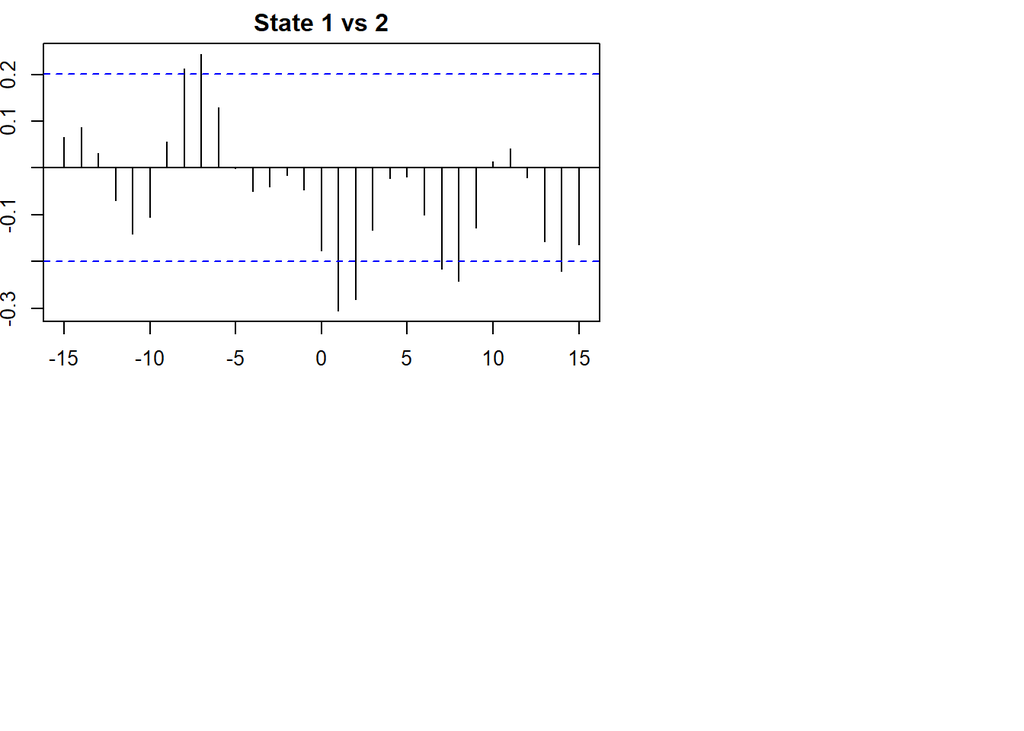

```r
## plot CCF's
ccf(proc_rot[1,],proc_rot[2,], lag.max = 15, main="")
title(main = "State 1 vs 2")
```

This model seems to explain primary producer and grazer dynamics best in state 1, and predator dynamics best in state two. Epischura has a strong negative trend in state two, compared to other species which are all postive in both states 1 and 2.

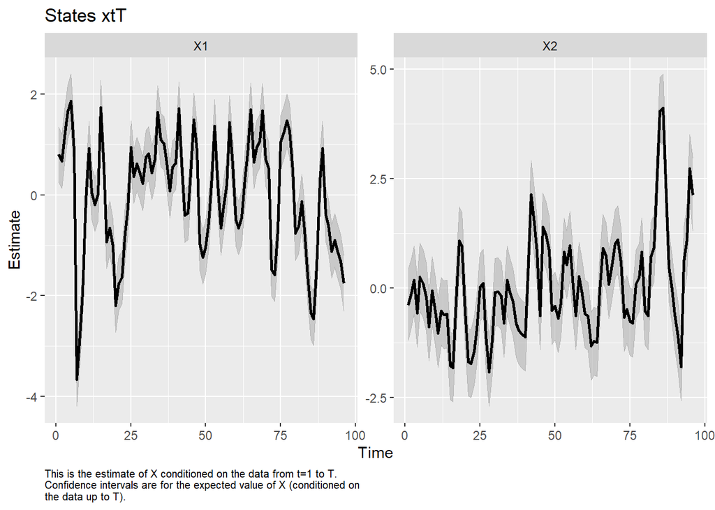

```
## plot.type = xtT
```

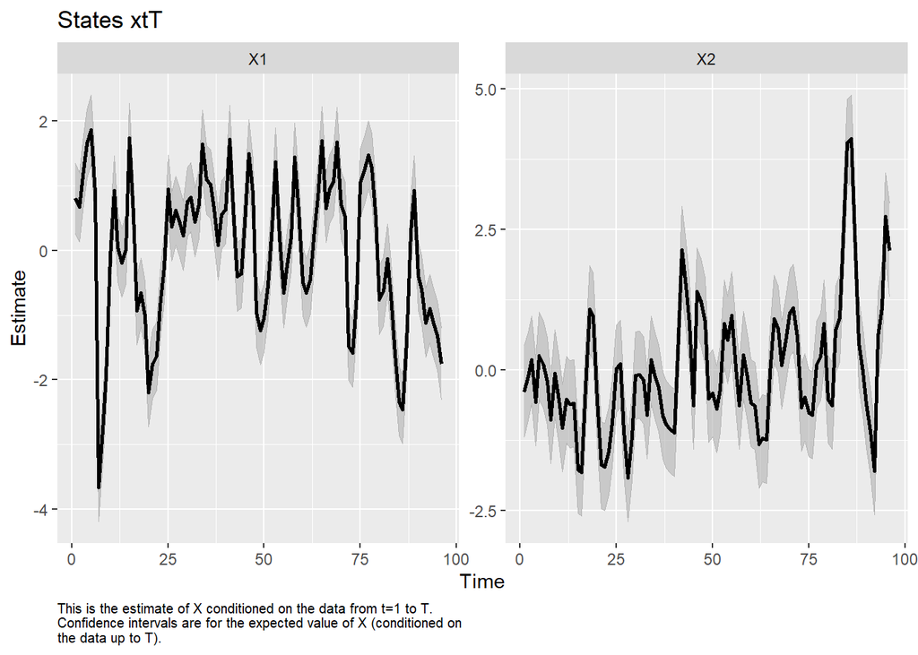

```
## Hit <Return> to see next plot (q to exit):
```

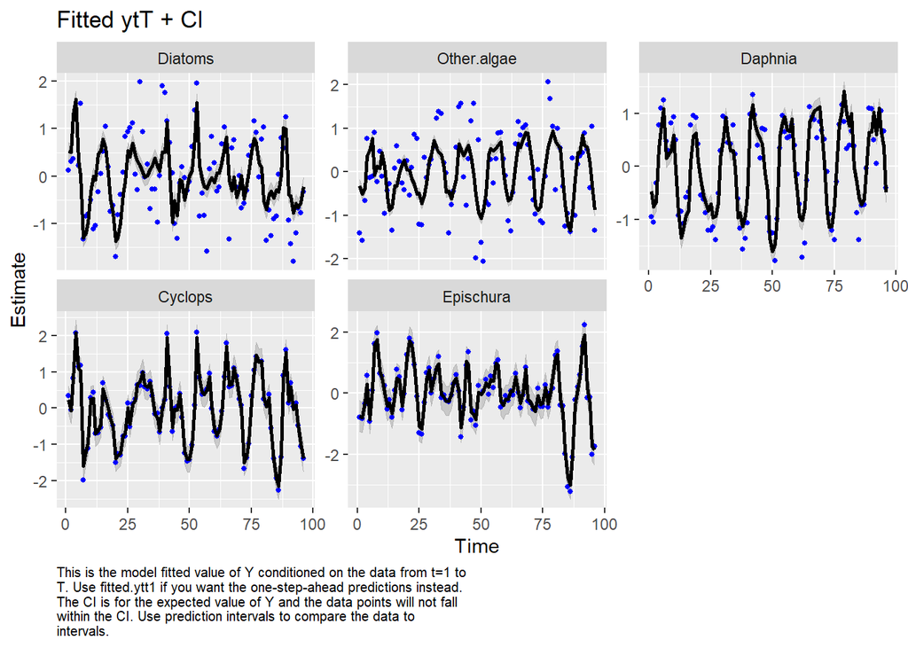

```
## plot.type = fitted.ytT
```

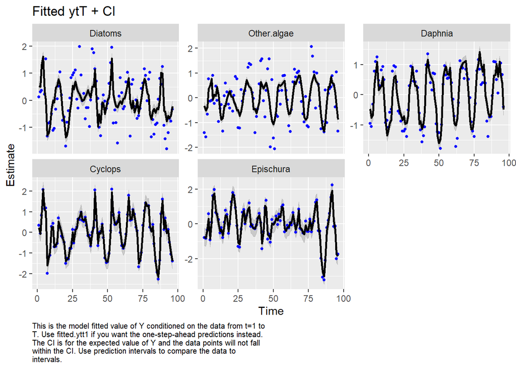

```
## Hit <Return> to see next plot (q to exit):
```

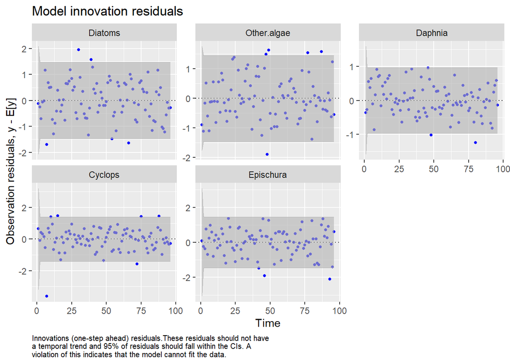

```
## plot.type = model.resids.ytt1
```

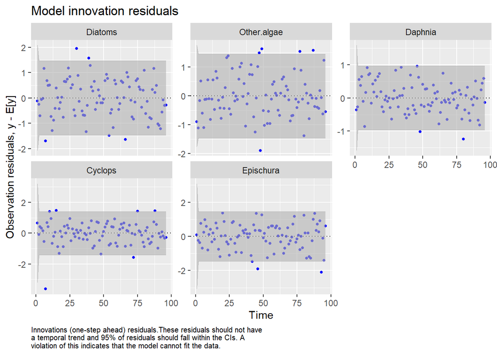

```
## Hit <Return> to see next plot (q to exit):
```

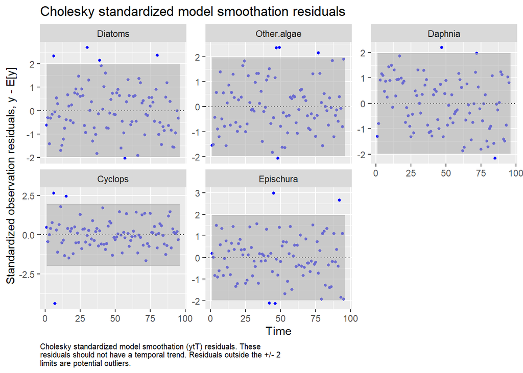

```
## plot.type = std.model.resids.ytT
```

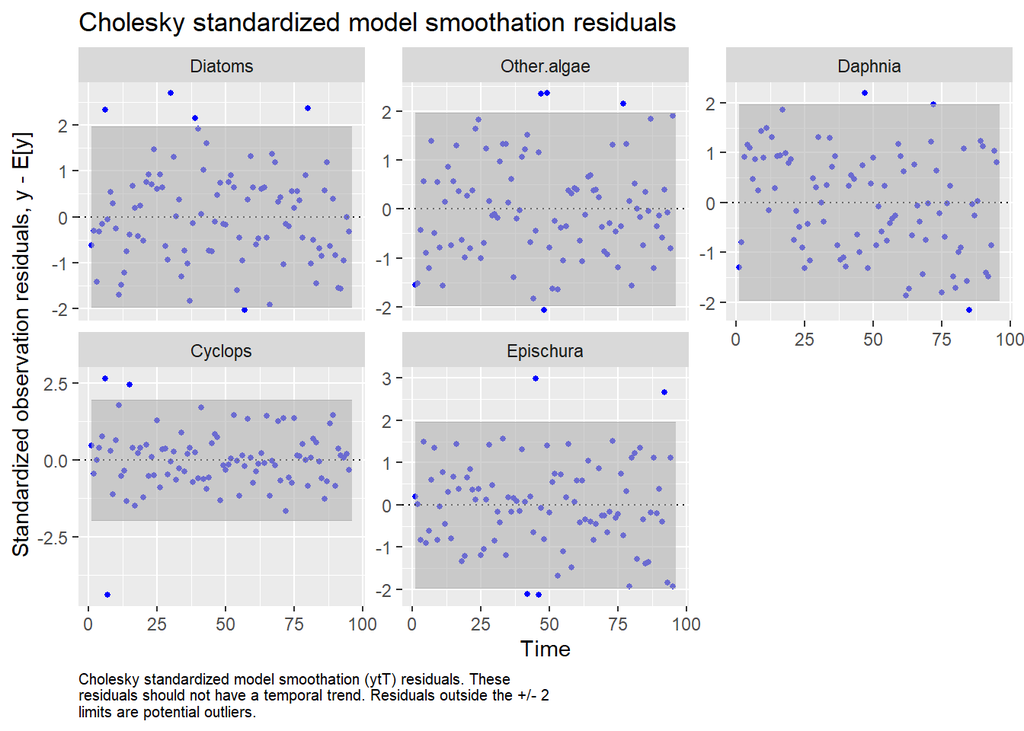

```
## Hit <Return> to see next plot (q to exit):
```

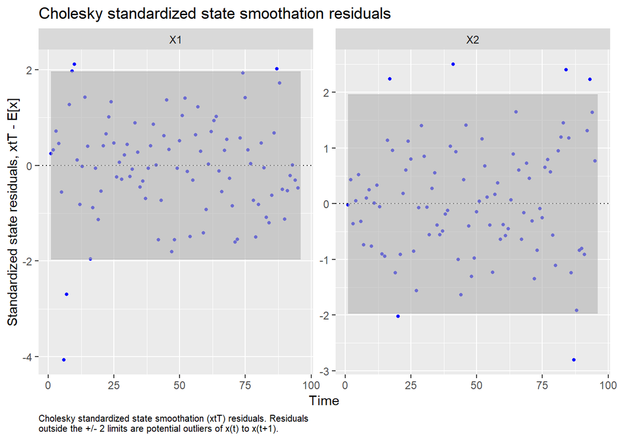

```
## plot.type = std.state.resids.xtT
```

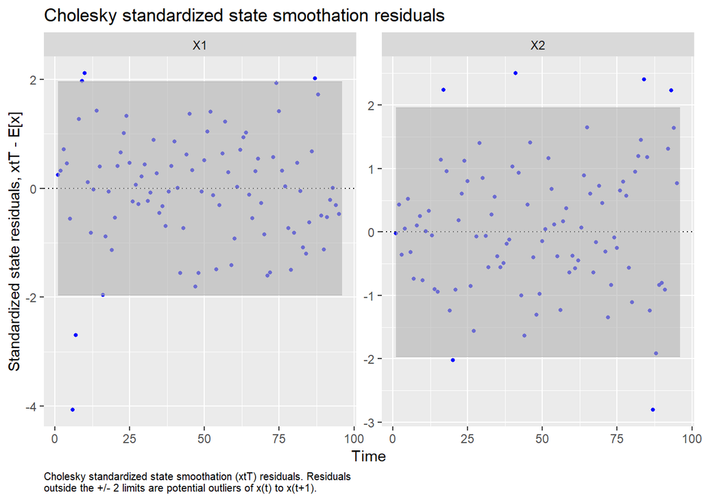

```
## Hit <Return> to see next plot (q to exit):
```

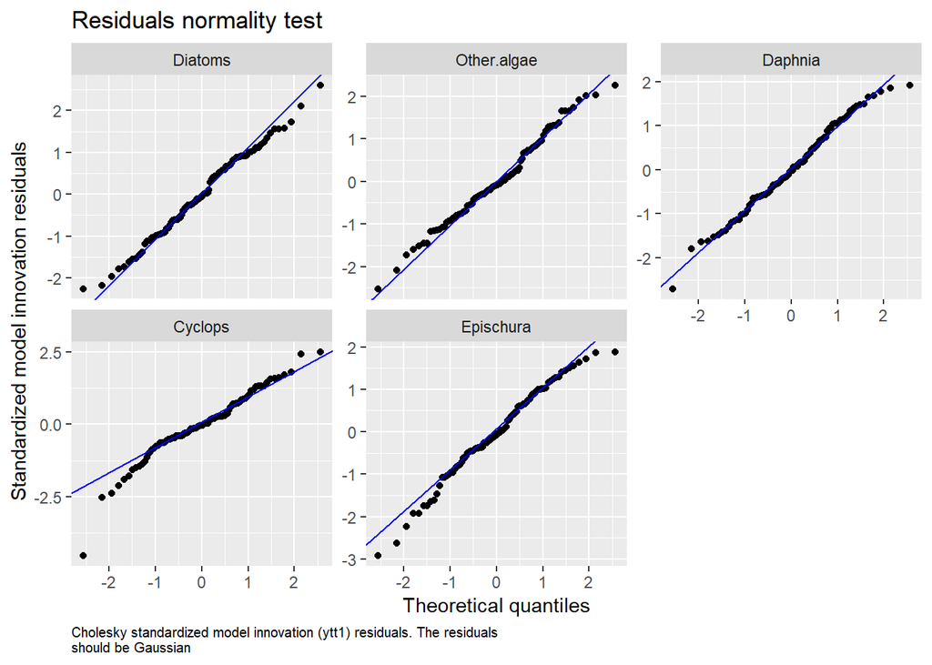

```
## plot.type = qqplot.std.model.resids.ytt1
```

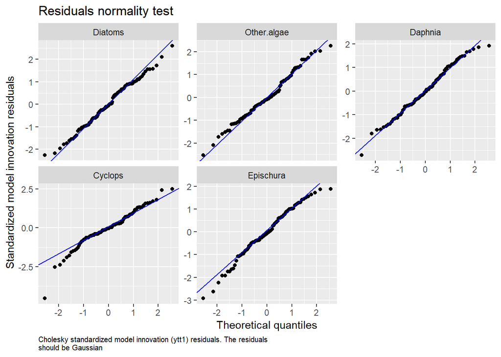

```
## Hit <Return> to see next plot (q to exit):
```

[4 more figures not shown]

```
## Hit <Return> to see next plot (q to exit):
```

```r
autoplot(best_fit)
```

### Model Fits

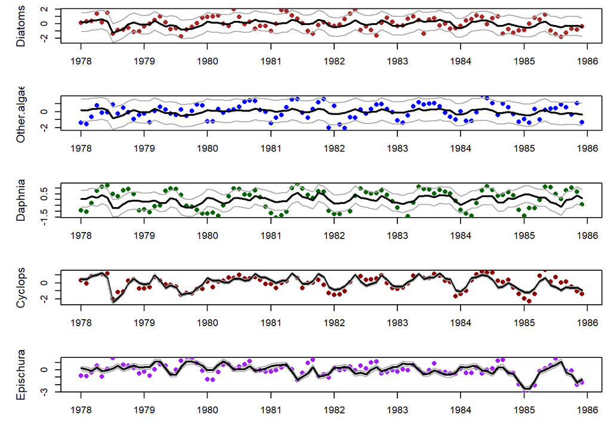

```r
get_DFA_fits <- function(MLEobj, dd = NULL, alpha = 0.05) {
    ## empty list for results
    fits <- list()
    ## extra stuff for var() calcs
    Ey <- MARSS:::MARSShatyt(MLEobj)
    ## model params
    ZZ <- coef(MLEobj, type = "matrix")$Z
    ## number of obs ts
    nn <- dim(Ey$ytT)[1]
    ## number of time steps
    TT <- dim(Ey$ytT)[2]
    ## get the inverse of the rotation matrix
    H_inv <- varimax(ZZ)$rotmat
    ## check for covars
    if (!is.null(dd)) {
        DD <- coef(MLEobj, type = "matrix")$D
        ## model expectation
        fits$ex <- ZZ %*% H_inv %*% MLEobj$states + DD %*% dd
    } else {
        ## model expectation
        fits$ex <- ZZ %*% H_inv %*% MLEobj$states
    }
    ## Var in model fits
    VtT <- MARSSkfss(MLEobj)$VtT
    VV <- NULL
    for (tt in 1:TT) {
        RZVZ <- coef(MLEobj, type = "matrix")$R - ZZ %*% VtT[,
            , tt] %*% t(ZZ)
        SS <- Ey$yxtT[, , tt] - Ey$ytT[, tt, drop = FALSE] %*%
            t(MLEobj$states[, tt, drop = FALSE])
        VV <- cbind(VV, diag(RZVZ + SS %*% t(ZZ) + ZZ %*% t(SS)))
    }
    SE <- sqrt(VV)
    ## upper & lower (1-alpha)% CI
    fits$up <- qnorm(1 - alpha/2) * SE + fits$ex
    fits$lo <- qnorm(alpha/2) * SE + fits$ex
    return(fits)
}


clr <- c("brown", "blue", "darkgreen", "darkred", "purple")
N_ts <- dim(plank_dat)[1]
w_ts <- seq(dim(plank_dat)[2])
## get model fits & CI's
mod_fit <- get_DFA_fits(best_fit)
## plot the fits
ylbl <- plank_taxa
par(mfrow = c(N_ts, 1), mai = c(0.5, 0.7, 0.1, 0.1), omi = c(0,
    0, 0, 0))
for (i in 1:N_ts) {
    up <- mod_fit$up[i, ]
    mn <- mod_fit$ex[i, ]
    lo <- mod_fit$lo[i, ]
    plot(w_ts, mn, xlab = "", ylab = ylbl[i], xaxt = "n", type = "n",
        cex.lab = 1.2, ylim = c(min(lo), max(up)))
    axis(1, 12 * (0:dim(plank_dat)[2]) + 1, yr_frst + 0:dim(plank_dat)[2])
    points(w_ts, plank_dat[i, ], pch = 16, col = clr[i])
    lines(w_ts, up, col = "darkgray")
    lines(w_ts, mn, col = "black", lwd = 2)
    lines(w_ts, lo, col = "darkgray")
}
```

These fits seem to be missing a lot of the interannual peaks and valleys for daphnia and the confidence intervals for cyclops and epischura are very tight and missing data. We may be able to find a better fitting model with seasonal considerations.

# Seasonal Model Exploration

**Describe the effects of environmental or dummy variables on (possibly seasonal) patterns in the data.**

## Seasonal Model Set-up

We decided to look at three seasonal patterns, an annual pattern (12 months), a six month pattern, and a 3 month pattern (Winter, Spring, Summer, Fall).

```r
TT <- dim(plank_dat)[2]

fits_season <- list()

out.tab.season <- NULL

model.states <- 1
names(model.states) <- c("two_states")

R.models <- c("diagonal and unequal")

# 12 month period
  cos.12 <- cos(2 * pi * seq(TT)/12)
  sin.12 <- sin(2 * pi * seq(TT)/12)
  c.Four_12 <- rbind(cos.12, sin.12)

# 6 month period
  cos.6 <- cos(2 * pi * seq(TT)/6)
  sin.6 <- sin(2 * pi * seq(TT)/6)
  c.Four_6 <- rbind(cos.6, sin.6)

# 3 month period
  cos.3 <- cos(2 * pi * seq(TT)/3)
  sin.3 <- sin(2 * pi * seq(TT)/3)
  c.Four_3 <- rbind(cos.3, sin.3)

  d10 = zscore(t(init_dat[,c("Temp","TP", "pH")]))
  d12 = rbind(c.Four_12, d10)
  d6 = rbind(c.Four_6, d10)
  d3 = rbind(c.Four_3, d10)

  d.models <- list(d10, d12, d6, d3)
  names(d.models) <- c("Temp,TP, and pH", "12 month", "6 month", "3 month")

  mod.list = list(
    A = "zero",
    Q = "identity",
    x0 = "zero"
  )

  start.time <- Sys.time()
    for (j in 1:length(d.models)){
      for(R.model in R.models){
        fit.model = c(list(m=i, R=R.model), mod.list)
        fit <- MARSS(plank_dat, model=fit.model,
                     form = "dfa", z.score = FALSE, silent = TRUE,
                     control=list(maxit=800, allow.degen=TRUE),
                     covariates = d.models[[j]])
        out=data.frame(States=names(model.states)[i-1],d=names(d.models)[j],R=R.model, #
                       logLik=fit$logLik, AICc=fit$AICc, num.param=fit$num.params,
                       num.iter=fit$numIter, converged=!fit$convergence,
                       stringsAsFactors = FALSE)
        out.tab.season=rbind(out.tab.season,out)
        fits_season=c(fits,list(fit))
      }
    }

  end.time <- Sys.time()

  elapsed.time <- round((end.time - start.time), 3)
  print(paste("Elapsed time for period:", elapsed.time))
```

```
## [1] "Elapsed time for period: 4.557"
```

```r
min.AICc <- order(out.tab.season$AICc)
out.tab.2 <- out.tab.season[min.AICc, ]
out.tab.2
```

```
##   States               d                    R    logLik      AICc num.param
## 3   <NA>         6 month diagonal and unequal -419.3891  938.3174        45
## 2   <NA>        12 month diagonal and unequal -447.2196  993.9783        45
## 1   <NA> Temp,TP, and pH diagonal and unequal -460.1765  996.0288        35
## 4   <NA>         3 month diagonal and unequal -459.1695 1017.8782        45
##   num.iter converged
## 3      406      TRUE
## 2      800     FALSE
## 1      800     FALSE
## 4      800     FALSE
```

# Seasonal Results

## Matrix for Best Seasonal Model

Process Error

Observation Error

$$\begin{bmatrix}
v_1\\
v_2\\
v_3\\
v_4\\
v_5\\
\end{bmatrix}
\sim MVN
\begin{pmatrix}
\begin{bmatrix}
0\\
0\\
0\\
0\\
0\\
\end{bmatrix},
\begin{bmatrix}
r_1 & 0& 0& 0& 0\\
0 & r_2& 0& 0& 0\\
0 & 0& r_3& 0& 0\\
0 & 0& 0& r_4& 0\\
0 & 0& 0& 0& r_5\\
\end{bmatrix}
\end{pmatrix}$$

## Plotting the Seasonal Model

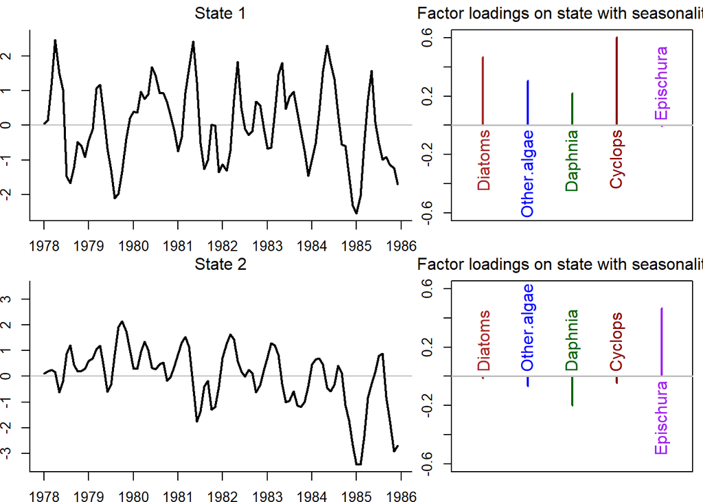

```r
# Rotating the model, plotting the states and loadings
best_fit_s <- fits_season[[3]]

# Get Z Estimations and rotate the data
## get the estimated ZZ
Z_est_s <- coef(best_fit_s, type = "matrix")$Z

## get the inverse of the rotation matrix
H_inv_s <- varimax(Z_est_s)$rotmat

## rotate factor loadings
Z_rot_s = Z_est_s %*% H_inv_s

## rotate processes
proc_rot_s = solve(H_inv_s) %*% best_fit_s$states

N_ts <- nrow(plank_dat)
m = ncol(Z_est)
## plot labels
ylbl <- plank_taxa
w_ts <- seq(mm)

## set up plot area
layout(matrix(1:4, m, 2), widths = c(3,2))
par(mai = c(0.3, 0.3, 0.3, 0.1), omi = c(0, 0, 0, 0))

## plot the processes
for(i in 1:m) {
  ylm <- c(-1, 1) * max(abs(proc_rot_s[i,]))
  ## set up plot area
  plot(w_ts,proc_rot_s[i,], type = "n", bty = "L",
       ylim = ylm, xlab = "", ylab = "", xaxt = "n")
  ## draw zero-line
  abline(h = 0, col = "gray")
  ## plot trend line
  lines(w_ts, proc_rot_s[i,], lwd = 2)
  lines(w_ts, proc_rot_s[i,], lwd = 2)
  ## add panel labels
  mtext(paste("State",i), side = 3, line = 0.5)
  axis(1, 12 * (0:mm) + 1, yr_frst + 0:mm)
}
## plot the loadings
minZ <- 0
ylm <- c(-1, 1) * max(abs(Z_rot_s))
for(i in 1:m) {
  plot(x = c(1:N_ts)[abs(Z_rot_s[,i])>minZ],
       y = as.vector(Z_rot_s[abs(Z_rot_s[,i])>minZ,i]),
       type = "h",
       lwd = 2, xlab = "", ylab = "", xaxt = "n", ylim = ylm,
       xlim = c(0.5, N_ts + 0.5), col = clr)
  for(j in 1:N_ts) {
    if(Z_rot_s[j,i] > minZ) {text(j, -0.03, ylbl[j], srt = 90, adj = 1, cex = 1.2, col = clr[j])}
    if(Z_rot_s[j,i] < -minZ) {text(j, 0.03, ylbl[j], srt = 90, adj = 0, cex = 1.2, col = clr[j])}
    abline(h = 0, lwd = 1.5, col = "gray")
  }
  mtext(paste("Factor loadings on state with seasonality", i), side = 3, line = 0.5)
}
```

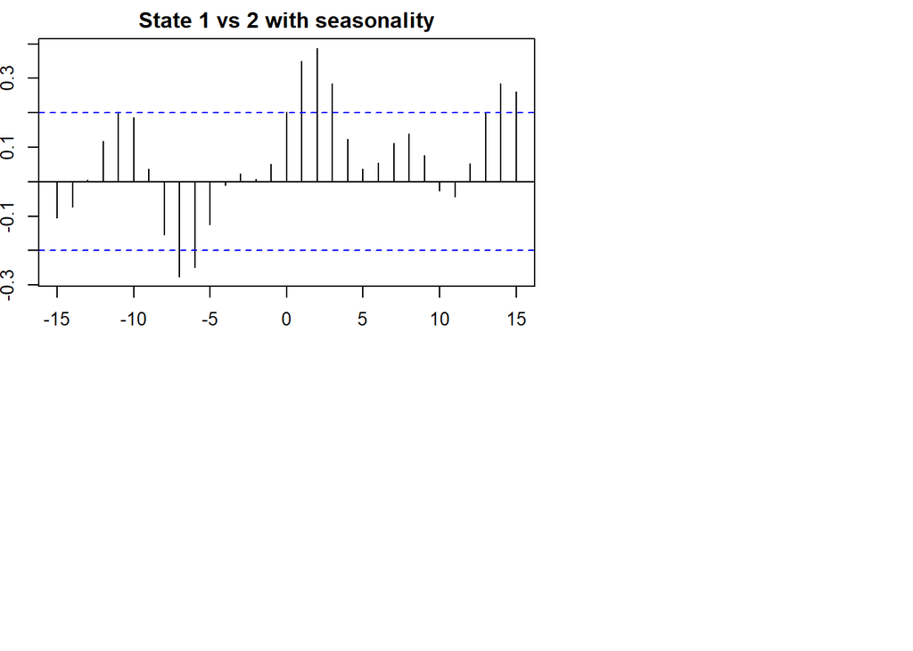

```r
## plot CCF's
ccf(proc_rot_s[1,],proc_rot_s[2,], lag.max = 15, main="")
title(main = "State 1 vs 2 with seasonality")
```

The factor loading seen in the model that is including seasonality seems to explain the dynamics of the speices better than the model that did not include seasonality, however, the sign of factor loading for Epishura, our predator species, changed to become positive in the seasonal model.

Factor loadings: * Pattern for primary producers and grazers is better explained by state one * Pattern for predator species is better explained by state two

CCF plot indicates that there is still some seasonal mechanism occurring that our model is not capturing.

### Additional Diagnostic

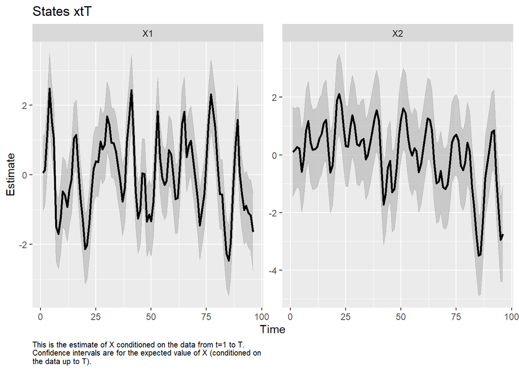

```
## plot.type = xtT
```

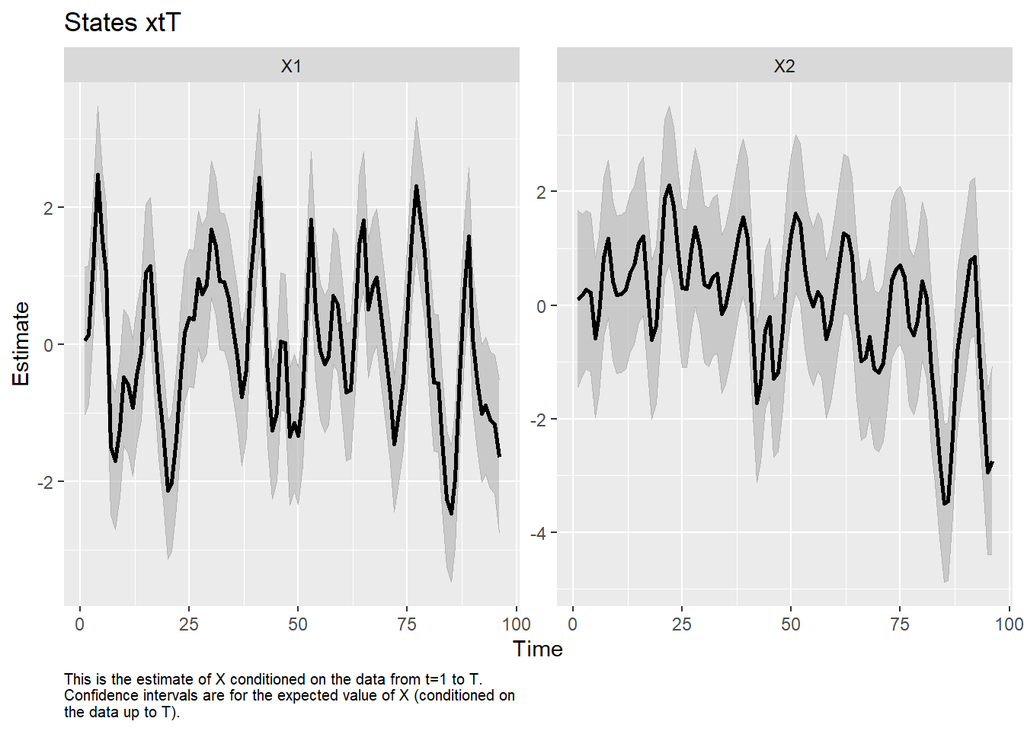

```
## Hit <Return> to see next plot (q to exit):
```

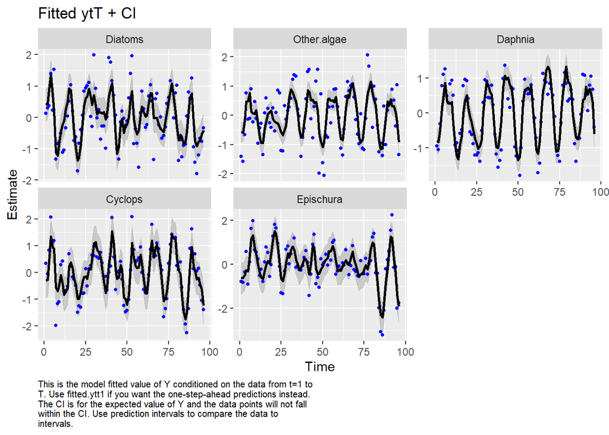

```
## plot.type = fitted.ytT
```

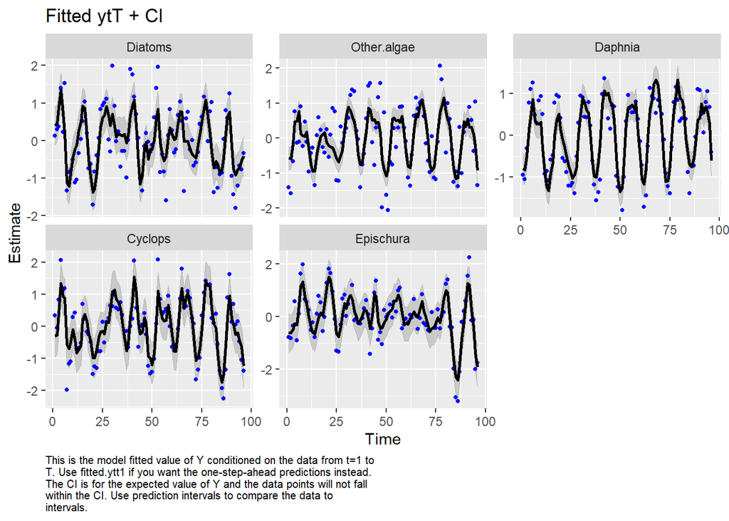

```
## Hit <Return> to see next plot (q to exit):
```

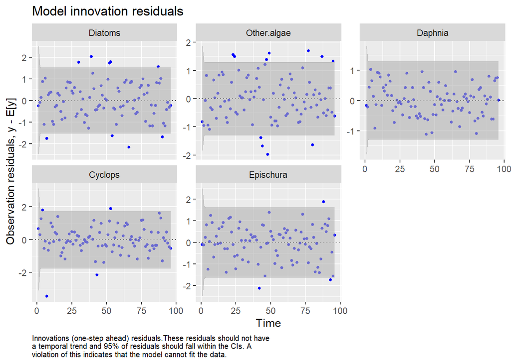

```
## plot.type = model.resids.ytt1
```

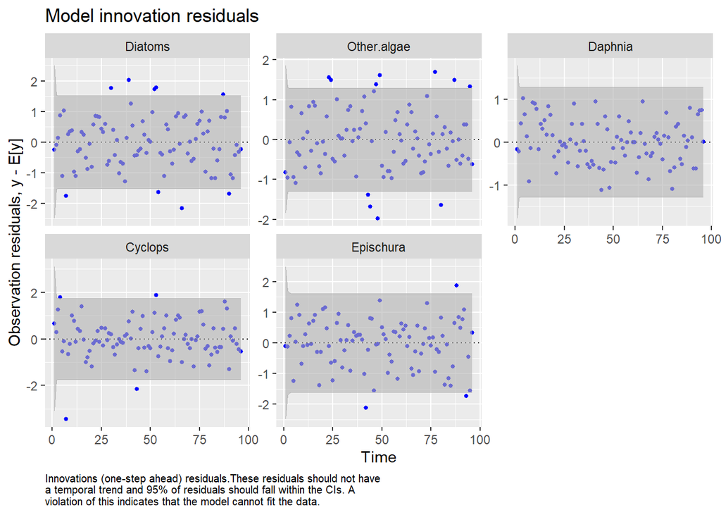

```
## Hit <Return> to see next plot (q to exit):
```

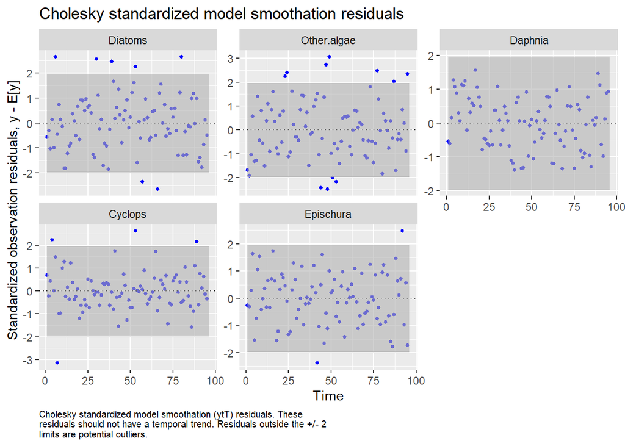

```
## plot.type = std.model.resids.ytT
```

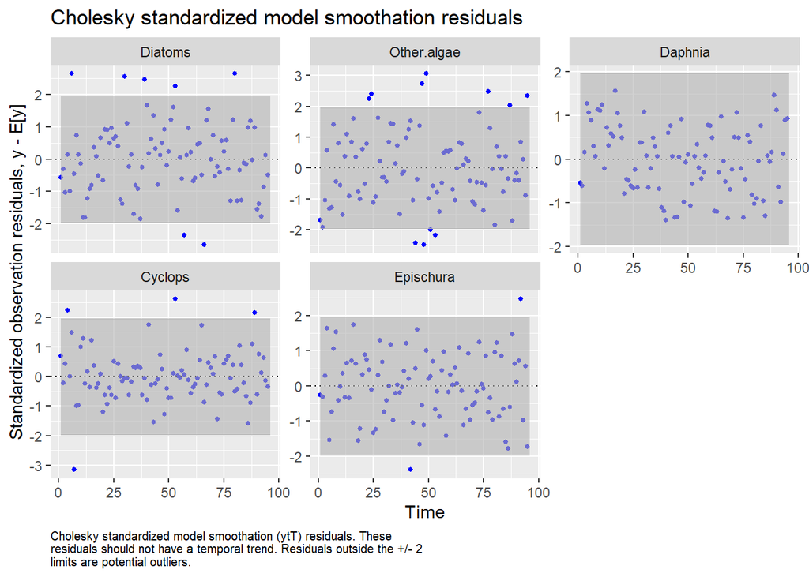

```
## Hit <Return> to see next plot (q to exit):
```

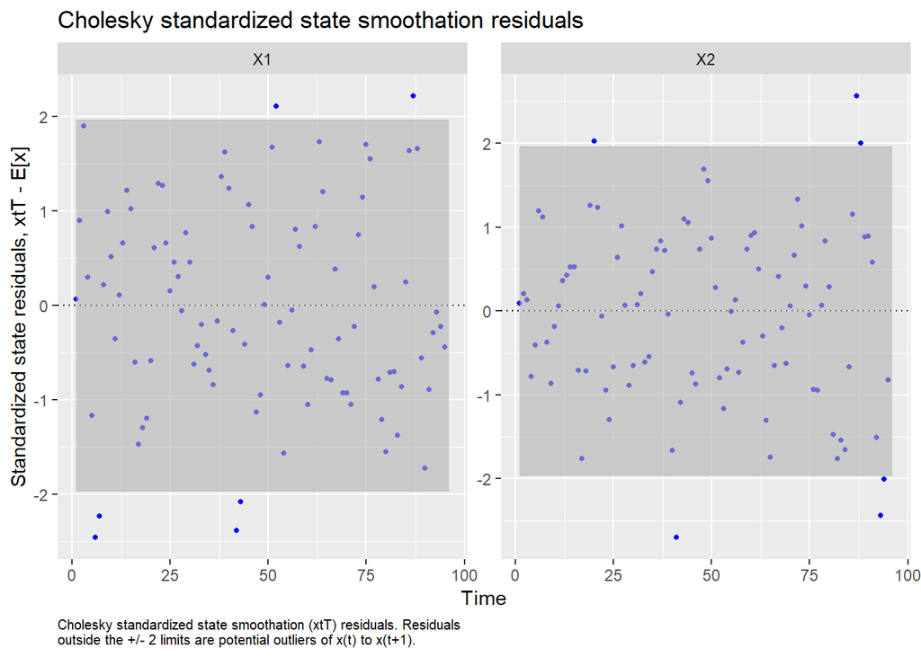

```
## plot.type = std.state.resids.xtT
```

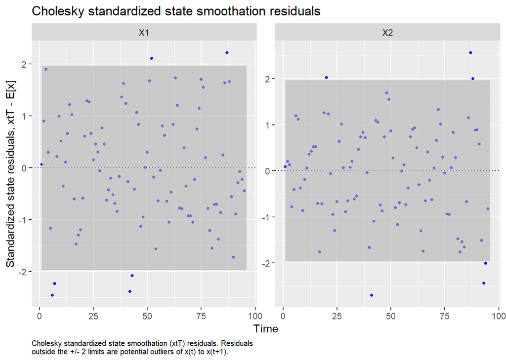

```
## Hit <Return> to see next plot (q to exit):
```

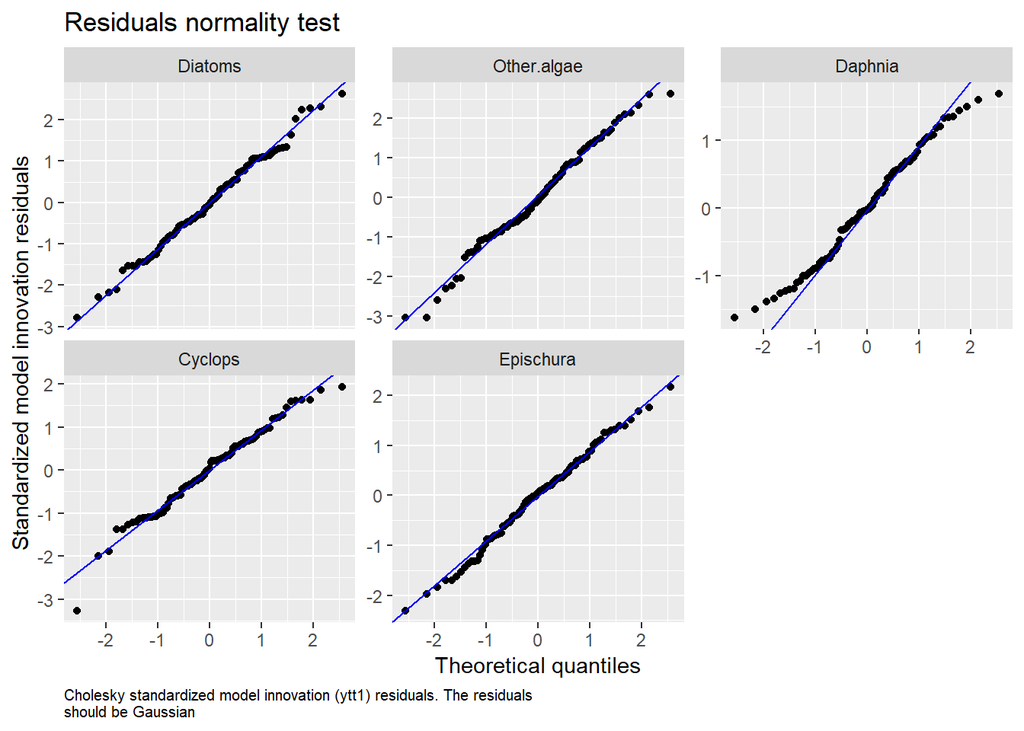

```
## plot.type = qqplot.std.model.resids.ytt1
```

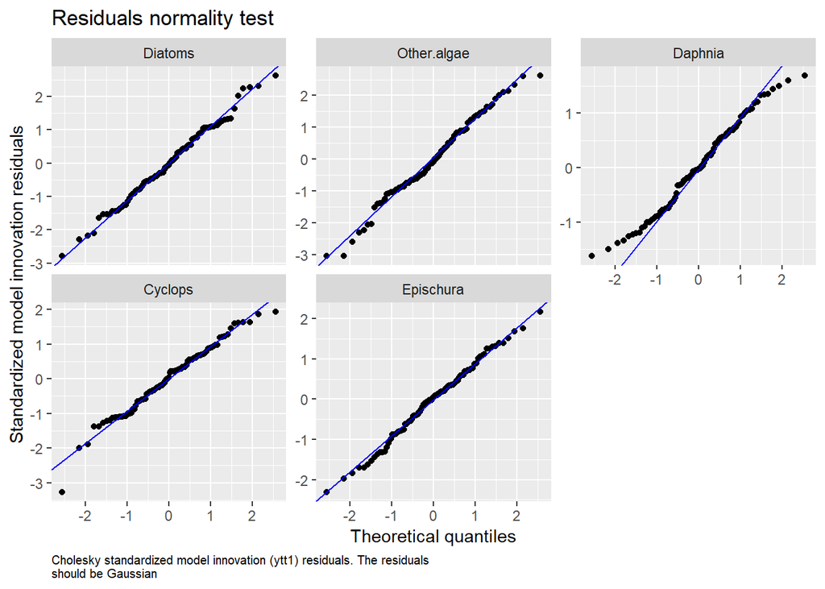

```
## Hit <Return> to see next plot (q to exit):
```

[4 more figures not shown]

```
## Hit <Return> to see next plot (q to exit):
```

```r
autoplot(best_fit_s)
```

This model is fitting the species better overall compared to the non-seaosnal model. Residuals and assumptions of normality look good overall. Daphnia still show some seasonal pattern not being captured in this model in the Cholesky residuals.

## Model Fits

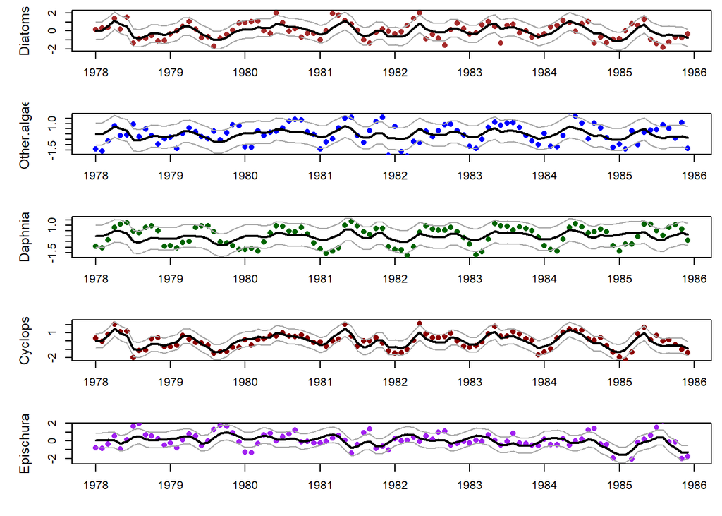

```r
clr <- c("brown", "blue", "darkgreen", "darkred", "purple")
N_ts <- dim(plank_dat)[1]
w_ts <- seq(dim(plank_dat)[2])
## get model fits & CI's
mod_fit_s <- get_DFA_fits(best_fit_s)
## plot the fits
ylbl <- plank_taxa
par(mfrow = c(N_ts, 1), mai = c(0.5, 0.7, 0.1, 0.1), omi = c(0,
    0, 0, 0))
for (i in 1:N_ts) {
    up <- mod_fit_s$up[i, ]
    mn <- mod_fit_s$ex[i, ]
    lo <- mod_fit_s$lo[i, ]
    plot(w_ts, mn, xlab = "", ylab = ylbl[i], xaxt = "n", type = "n",
        cex.lab = 1.2, ylim = c(min(lo), max(up)))
    axis(1, 12 * (0:dim(plank_dat)[2]) + 1, yr_frst + 0:dim(plank_dat)[2])
    points(w_ts, plank_dat[i, ], pch = 16, col = clr[i])
    lines(w_ts, up, col = "darkgray")
    lines(w_ts, mn, col = "black", lwd = 2)
    lines(w_ts, lo, col = "darkgray")
}
```

Still not fitting other algae and daphina particularly well, but the model is trying to follow the trends and most of the data are captured within the confidence intervals. The confidence intervals are larger for cyclops and epishura compared to the non-seasonal model and more of the data are being captured.

# Discussion

In this exercise our goal was to capturing the dynamics of predator and prey species in Lake Washington in the late 70’s and early 80’s.

Seasonal model (six month period) fit better and the factor loading results showed more of a deviance between state one and state two for primary producers and grazers, and predators.

All three environmental covariates were included in the best fit model, showing that they are explaning levels of variability for the selected species in the selected time period.

Epishura seem to have an offset from the other species. We’re fitting two independent states to five species, and while one state captured the dynamics of grazers and primary producers relatively well, epishura was not captured at all in this state, indicating independence between these two groups of plankton in the time period analyzed.

All three environmental covariates were included in the best fit model, showing that they are explaning levels of variability for the selected species in the selected time period.

# Team contributions

Madi set up plotting code for the entire time series for all species to select species of interest in data rich periods.

Eric wrote the majority of the model set up code and created functions used for plotting.

Maria took the code that Eric wrote, optimized it for our covariate process, and helped with convergence issues, and set up the initial model that included seasonal considerations.

Madi took the Maria’s code and edited to include seasonal considerations for three periods, added commentary for diagnostics, and set-up the Rmarkdown structure and coded the model matrices.

All team members helped with defining the matrices for the selected models, interpretation of results, and writing of the report.